# Case 4intelligence

## PARTE C

**1. Importe a base “rendimento_efetivo_real.csv”.**

```r
rendimento <- read_csv2("data/rendimento_efetivo_real.csv")
```

```
i Using "','" as decimal and "'.'" as grouping mark. Use `read_delim()` for more control.
* `` -> ...3
```

**2. Renomeie as colunas para que tenhamos ”data”e ”renda”.**

```r
colnames(rendimento) <- c("data", "renda", "NA")

rendimento <- rendimento %>%
  select(data, renda)
```

**3. e a coluna data para o formato YYYY-MM-DD. (Utilize 01 quando não houver especificado o dia).**

```r
rendimento <- rendimento %>%
  mutate(data = parse_date_time(data, orders = "Ym"))
```

**4. Junte com a base anterior já organizada.**

```r
pmc_rend <- pmc %>%
  full_join(rendimento) %>%
  select(data:br, renda) %>%
  filter(!is.na(renda))
```

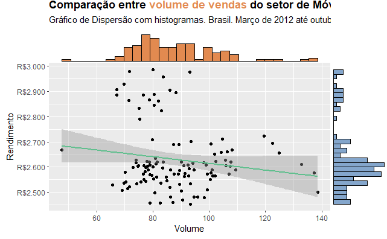

**6. Crie um modelo estatístico que estime a relação entre volume de vendas de móveis e eletrodomésticos com o rendimento real médio efetivo**

Dado que os dados são duas séries temporais, é necessário estimar um modelo de séries temporais multivariado. Podemos fazer um modelo tipo VAR ou tipo VECM, a depender do resultado do teste de cointegração, com a metodologia de Johansen. Além disso, vamos fazer o teste da raiz unitária, ADF (Augmented Dickley-Fuller) para saber se as séries são não-estacionárias ou estacionárias.

```r
# Criando as séries

pmc_wide <- pmc_rend %>%
  pivot_wider(names_from = setor,
              values_from = br)

serie_renda <- ts(pmc_wide$renda, start = c(2012, 03), frequency = 12)
serie_vol <- ts(pmc_wide$`Móveis e eletrodomésticos`, start = c(2012, 03), frequency = 12)

# Teste de raiz unitária

summary(ur.df(serie_renda))
```

```
###############################################
# Augmented Dickey-Fuller Test Unit Root Test #
###############################################

Test regression none


Call:
lm(formula = z.diff ~ z.lag.1 - 1 + z.diff.lag)

Residuals:
     Min       1Q   Median       3Q      Max
-226.470  -19.924    1.952   22.314  230.944

Coefficients:
             Estimate Std. Error t value Pr(>|t|)
z.lag.1    -0.0006291  0.0029525  -0.213 0.831650
z.diff.lag  0.3373816  0.0877861   3.843 0.000202 ***
---
Signif. codes:  0 ‘***’ 0.001 ‘**’ 0.01 ‘*’ 0.05 ‘.’ 0.1 ‘ ’ 1

Residual standard error: 83.07 on 112 degrees of freedom
Multiple R-squared:  0.1168,    Adjusted R-squared:  0.101
F-statistic: 7.403 on 2 and 112 DF,  p-value: 0.0009559


Value of test-statistic is: -0.2131

Critical values for test statistics:
      1pct  5pct 10pct
tau1 -2.58 -1.95 -1.62
```

```r
summary(ur.df(serie_vol))
```

```
###############################################
# Augmented Dickey-Fuller Test Unit Root Test #
###############################################

Test regression none


Call:
lm(formula = z.diff ~ z.lag.1 - 1 + z.diff.lag)

Residuals:
    Min      1Q  Median      3Q     Max
-33.114  -5.871   2.328   8.734  41.628

Coefficients:
           Estimate Std. Error t value Pr(>|t|)
z.lag.1    -0.01091    0.01414  -0.772    0.442
z.diff.lag -0.06523    0.09408  -0.693    0.490

Residual standard error: 13.46 on 112 degrees of freedom
Multiple R-squared:  0.01021,   Adjusted R-squared:  -0.007468
F-statistic: 0.5775 on 2 and 112 DF,  p-value: 0.563


Value of test-statistic is: -0.7716

Critical values for test statistics:
      1pct  5pct 10pct
tau1 -2.58 -1.95 -1.62
```

Ambas as séries não rejeitaram a hipótese nula, de raiz unitária, pois os valores das estatísticas do teste são maiores que os valores de referência, logo são séries não estacionárias. Nosso modelo precisa ser I(1) para ambas séries.

Agora, descobrir a quantidade ótima de lags a serem usados

```r
VARselect(serie_renda_vol, lag.max = 6)$selection
```

```
AIC(n)  HQ(n)  SC(n) FPE(n)
     5      5      4      5
```

Vamos usar para a análise o método AIC, então teremos 5.

Vamos testar a cointegração, estimar o modelo VECM e testá-lo para saber se é válido.

```r
summary(jotest1)
```

```
######################
# Johansen-Procedure #
######################

Test type: maximal eigenvalue statistic (lambda max) , with linear trend

Eigenvalues (lambda):
[1] 0.15364830 0.04498908

Values of teststatistic and critical values of test:

          test 10pct  5pct  1pct
r <= 1 |  5.16  6.50  8.18 11.65
r = 0  | 18.68 12.91 14.90 19.19

Eigenvectors, normalised to first column:
(These are the cointegration relations)

               serie_renda.l4 serie_vol.l4
serie_renda.l4       1.000000      1.00000
serie_vol.l4         6.970768    -10.31784

Weights W:
(This is the loading matrix)

              serie_renda.l4 serie_vol.l4
serie_renda.d    -0.01254059 -0.083093242
serie_vol.d      -0.04331669  0.002483291
```

```r
serial.test(modelo_vecvar)
```

```
    Portmanteau Test (asymptotic)

data:  Residuals of VAR object modelo_vecvar
Chi-squared = 149.7, df = 50, p-value = 7.011e-12
```

```r
coef(modelo_var)
```

```
$serie_renda
                  Estimate   Std. Error    t value     Pr(>|t|)
serie_renda.l1   0.9650790   0.08515303 11.3334667 8.144990e-20
serie_vol.l1     2.7906775   0.49486670  5.6392509 1.504804e-07
serie_renda.l2   0.1254914   0.12592814  0.9965316 3.213273e-01
serie_vol.l2     0.7786176   0.60094695  1.2956512 1.979918e-01
serie_renda.l3  -0.3887768   0.12184744 -3.1906848 1.881613e-03
serie_vol.l3    -0.4714358   0.57346692 -0.8220802 4.129302e-01
serie_renda.l4   0.2025726   0.08321574  2.4343065 1.664066e-02
serie_vol.l4    -2.3279342   0.52223532 -4.4576346 2.115125e-05
const          184.1357762 177.24846685  1.0388568 3.013039e-01

$serie_vol
                   Estimate  Std. Error    t value     Pr(>|t|)
serie_renda.l1  -0.07920176  0.01701312 -4.6553341 9.672733e-06
serie_vol.l1     0.67408556  0.09887173  6.8177787 6.444032e-10
serie_renda.l2   0.08675693  0.02515977  3.4482400 8.185545e-04
serie_vol.l2    -0.09154825  0.12006599 -0.7624828 4.475145e-01
serie_renda.l3  -0.06063433  0.02434447 -2.4906820 1.434783e-02
serie_vol.l3     0.06282534  0.11457563  0.5483307 5.846513e-01
serie_renda.l4   0.01224576  0.01662606  0.7365401 4.630763e-01
serie_vol.l4     0.02706451  0.10433983  0.2593881 7.958535e-01
const          136.36061907 35.41329837  3.8505484 2.048851e-04
```

Testes de diagnóstico

```r
summary(ur.df(erro))
```

```
###############################################
# Augmented Dickey-Fuller Test Unit Root Test #
###############################################

Test regression none


Call:
lm(formula = z.diff ~ z.lag.1 - 1 + z.diff.lag)

Residuals:
     Min       1Q   Median       3Q      Max
-249.962  -31.956    6.433   37.692  206.415

Coefficients:
           Estimate Std. Error t value Pr(>|t|)
z.lag.1    -0.75076    0.11045  -6.797 5.59e-10 ***
z.diff.lag  0.09365    0.09298   1.007    0.316
---
Signif. codes:  0 ‘***’ 0.001 ‘**’ 0.01 ‘*’ 0.05 ‘.’ 0.1 ‘ ’ 1

Residual standard error: 81.31 on 111 degrees of freedom
Multiple R-squared:  0.3484,    Adjusted R-squared:  0.3367
F-statistic: 29.68 on 2 and 111 DF,  p-value: 4.725e-11


Value of test-statistic is: -6.7971

Critical values for test statistics:
      1pct  5pct 10pct
tau1 -2.58 -1.95 -1.62
```

**7. Caso ache apropriado, inclua mais variáveis na análise. Repita o processo e verifique se o resultado se mantém. (Utilize pacotes de APIs para baixar os dados, caso seja arquivo externo ao código, anexe a fonte – sugerimos SGS, Sidra e IPEA)**